# academic_mastery

Kevin Gilds, MPA

June 14, 2016

# Academic Mastery

The Academic Mastery questions gauge a student’s attitude towards school and education. Questions that measure Academic Mastery include the following.

- It’s important to me that I improve my skills this year in school
- It’s important to me that I really understand my class work
- Learning at school is important to me
- One of my goals in school is to learn as much as I can
- The things I am learning in school will help me later in life

The number of pre and post survey that could be matched is **330**, and the percent of students with a successful outcome is **88.79%**

1. The number of students achieving the academic engagement outcome at a high level is **282**
2. The number of students who did not achieve outcome at high level but increased their outcome score is **11**

The improvement in outcome scores is graphically represented below.

The percent of students who went from low achievement to high achievement is **24.24%** The number of students who had the opportunity to improve their academic engagement outcome score is **200**, and their mean increase in outcome score is **0.4092**

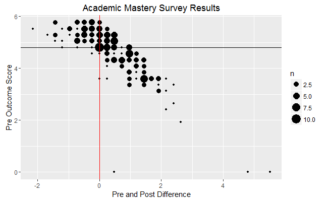

### Statistical Tests

Two statistical tests were administered on the matched survey results the Wilcox test and Cohen’s D test.

The outcome distributions did not approximate a normal distribution, thus a Wilcox.test was administered and the results show that the difference between the pre and post outcome scores are significant at .05 level.

```
---------------------------------------------------------
 Test statistic      P value      Alternative hypothesis
---------------- --------------- ------------------------
     13671       0.0001128 * * *           less
---------------------------------------------------------

Table: Wilcoxon signed rank test with continuity correction: `am_2016$Pre` and `am_2016$Post`
```

The Cohen D test indicates that the effect was small.

```
Cohen's d

d estimate: -0.2181761 (small)
95 percent confidence interval:
        inf         sup
-0.37172858 -0.06462362
```

## Cross Validation of Academic Mastery

#### Pre Parent Survey

- Question 1: She is motivated to graduate high school
- Question 3: She has a Good Attitude About School

Results based on 466 responses.

```
  Item       low  neutral     high     mean        sd
2   Q3 0.6437768 2.360515 96.99571 6.510730 0.7957499
1   Q1 0.2145923 7.296137 92.48927 6.630901 0.8829508
```

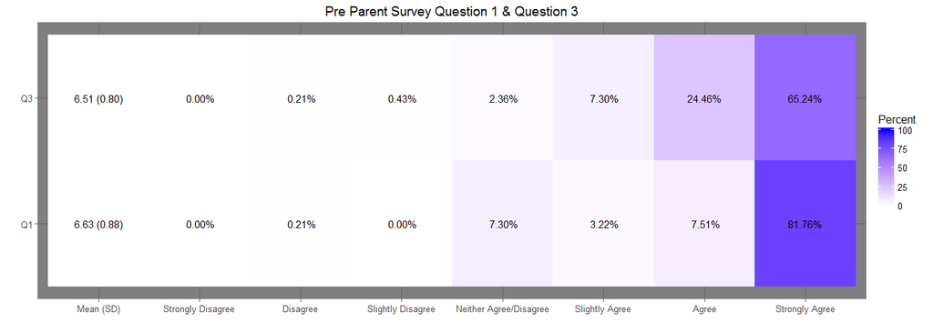

### Post Parent Survey

- Question 1: She is motivated to graduate high school
- Question 3: She has a Good Attitude About School

### Teacher Post Survey

- Question 1: She is motivated to graduate high school
- Question 3: She has a Good Attitude About School